# Modeling Exoplanet Counts

Using Poisson and Negative Binomial models.

Author

James Brainard

# Introduction

#### What factors link most significantly to modeling the number of exoplanets in a star system?

Formation of star, exoplanets, and the systems they inhabit have long been the topic of scientific research. Studying what kinds of factors contribute most heavily to the number of exoplanets in a star system can help us understand what influences the planet count of these systems.

#### The Dataset

Understanding data is vital to understanding outputs. This dataset comes from the NASA Exoplanet Science Institute. It is organized such that each row represents a composite planetary observation from all observatories that have seen the planet. Observatories will sometimes take observe different measurements for the same planet, so a composite table gives the most accurate data available.

#### Citation

NASA Exoplanet Archive. (2024). Planetary Systems Composite Data Table [Data set]. NASA Exoplanet Science Institute. https://doi.org/10.26133/NEA13

| Variable | Description | Explanation |
| --- | --- | --- |
| `sy_pnum` | Number of planets in the system | Response variable |
| `sy_snum` | Number of stars in the system | How many stars are in the system (there can be more than one!) |
| `st_mass` | Stellar mass | The weight of the star compared to the Sun |
| `st_rad` | Stellar radius | The size of the star compared to the Sun |
| `st_lum` | Stellar luminosity | How bright the star is compared to the Sun |
| `st_met` | Stellar metallicity | How much heavy elements (like iron) the star has |
| `pl_orbper` | Orbital period | How long a planet takes to orbit its star (in days) |
| `pl_orbsmax` | Semi-major axis | The average distance between the planet and the star (in AU) |
| `pl_orbeccen` | Eccentricity | How oval-shaped the planet’s orbit is (0 = circle, 1 = line) |
| `st_age` | Stellar age (in gigayears) | How old the star is, in billions of years |
| `pl_insol` | Insolation flux | How much sunlight a planet gets compared to Earth |
| `st_logg` | Stellar surface gravity | The strength of gravity on the star’s surface |
| `st_dens` | Stellar density | How tightly packed the star’s material is |

# Exploratory Data Analysis

First, we can explore a distribution of all features to see if there are any standouts or abnormal data. Each axis of these distributions is scaled to the data that it measures, so the numbered labels are largely useless unless the reader is an expert in astronomy. However, for now, the actual values are not as important as the distributions.

A few variables, such as st_met and st_lum, seem to follow (somewhat) normal distributions, whereas most seem to have more right-skewed distributions.

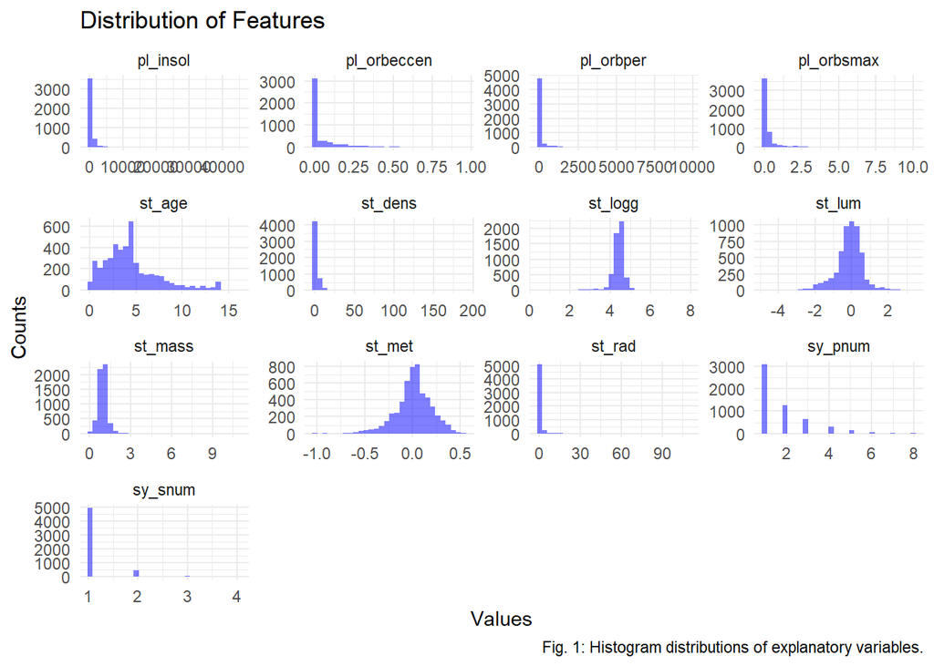

Next, we can check the distribution of the response variable - the count of planets in a system. This distribution has a right skew as well, and it gives quite a level of appreciation for the fact that we live in an 8-planet system.

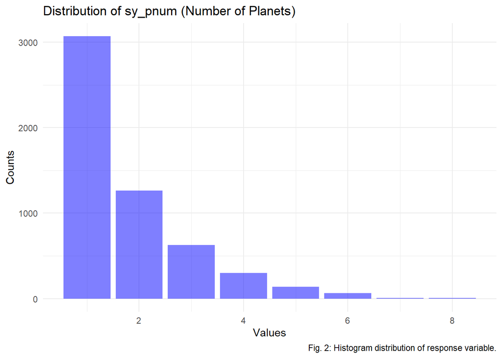

While checking over our data before running any models, it can be useful to see if the data possesses traits that would be expected based on known physical laws. To start with, a larger star is expected to be more luminous, which is confirmed by Fig. 3.

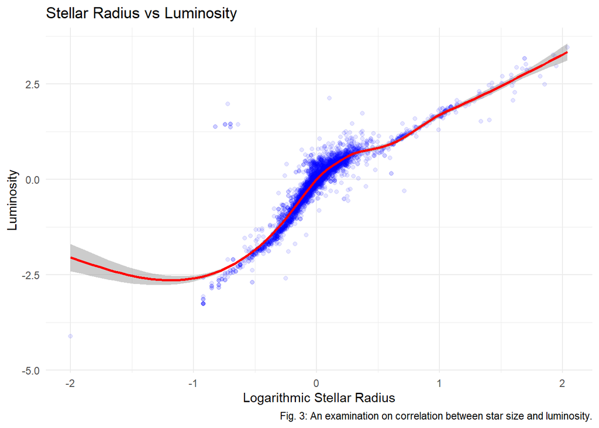

Kepler’s Third Law states that the farther a planet is from its star, the longer it takes to orbit, given by the equation:

$$P^2 \propto a^3$$

[figure not shown]

With explanatory variables that are so directly correlated, it will be important to keep collinearity in mind when narrowing down our important features.

# Model Fitting / Model Selection

First, a Poisson model is fit to the data.

#### Why a Poisson model?

The number of planets in a system is count data, discrete and non-negative. Poisson distributions also assume that mean and variance are equal, and while this rarely ever occurs with real data, variance (1.36) and mean (1.80) for ‘sy_pnum’ are not terribly far apart.

Next, a negative binomial model is fit to the data.

#### Why a Negative Binomial model?

Negative Binomial models add a dispersion parameter, making them more flexible than Poisson models. With such a high number of systems with only 1 or 2 planets, overdispersion is to be anticipated.

# Model Comparison

## Missing Data

Missing data is a huge problem in many astronomy datasets. There is so much to collect - and so little funding and time - that observatories can’t get data for everything. As a result, there is a large amount of missing data in the exoplanet dataset. Two approaches to this missing data problem are row removal and imputation.

### Row Removal

Row removal constitutes removing any row of data where an NA value exists. This removes 1927 out of 5482 rows, which is a large chunk.

Using this method, both of the models are actually nearly identical. Both include the same significant variables with nearly identical p-values:

| Variable | Poisson Estimate | Poisson p-value | Negative Binomial Estimate | Negative Binomial p-value |
| --- | --- | --- | --- | --- |
| `st_met` | -0.4569 | 0.000472 *** | -0.4569 | 0.000473 *** |
| `pl_orbper` | -0.001757 | 3.89e-07 *** | -0.001757 | 3.91e-07 *** |
| `pl_orbsmax` | 1.4170 | 1.59e-09 *** | 1.4170 | 1.60e-09 *** |
| `pl_orbeccen` | -0.6658 | 0.000377 *** | -0.6658 | 0.000378 *** |
| `pl_insol` | -5.366e-05 | 0.035062 * | -5.365e-05 | 0.035101 * |
| `st_dens` | 0.01413 | 1.88e-05 *** | 0.01413 | 1.88e-05 *** |

Both models also have the same amount of residual deviance.

| Model | Residual Deviance |
| --- | --- |
| Poisson | 660.77 |
| Negative Binomial | 660.63 |

This makes them difficult to compare. What, then, of the second method?

### Imputation

Imputation fills in missing values with various methods. For this data, KNN-imputation will be used, which picks similar observations to fill in missing values.

| Variable | Poisson Estimate (Imputed) | Poisson p-value | Negative Binomial Estimate (Imputed) | Negative Binomial p-value |
| --- | --- | --- | --- | --- |
| `sy_snum` | 0.1403 | 8.07e-07 *** | 0.1403 | 8.09e-07 *** |
| `st_met` | -0.1238 | 0.0324 * | -0.1238 | 0.0324 * |
| `st_lum` | -0.0562 | 0.0542 . | -0.0562 | 0.0542 . |
| `pl_orbeccen` | -0.3588 | 2.49e-05 *** | -0.3588 | 2.49e-05 *** |
| `pl_insol` | -1.052e-04 | 6.35e-10 *** | -1.052e-04 | 6.37e-10 *** |

## Row-Removal vs Imputation & Poisson vs Negative Binomial

Again, both models have approximately the same amount of residual deviance.

| Model | Residual Deviance |
| --- | --- |
| Poisson | 3235.1 |
| Negative Binomial | 3234.6 |

All four models pass the chi-squared Goodness-of-Fit test, with no evidence to show that any of them are a bad model (p ~= 1 for all)

```
[1] "Poisson Model (Original Data) Goodness-of-Fit p-value: 1"
```

```
[1] "Poisson Model (Imputed Data) Goodness-of-Fit p-value: 1"
```

```
[1] "Negative Binomial Model (Original Data) Goodness-of-Fit p-value: 1"
```

```
[1] "Negative Binomial Model (Imputed Data) Goodness-of-Fit p-value: 1"
```

Given that the output between Poisson/Negative Binomial is so similar, a lack of overdispersion in our data as seen by the dispersion parameter below lends to the choice of a simpler Poisson model.

```
[1] 0.754815
```

Still, we have to compare the row-removal and imputation-based models. Comparing the two Poisson models according to AIC is difficult, since there is a different number of observations in each model. The next best approach could be to compare the residuals vs fitted plots for each model:

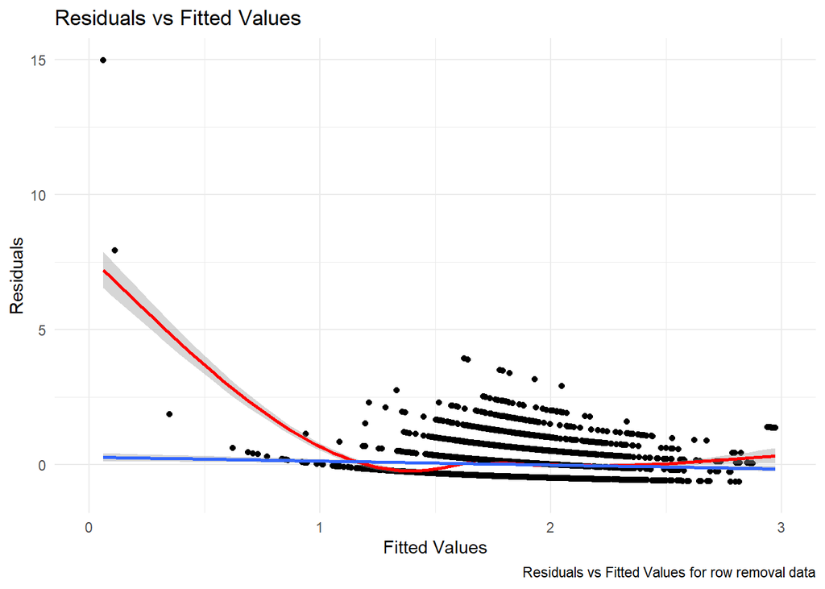

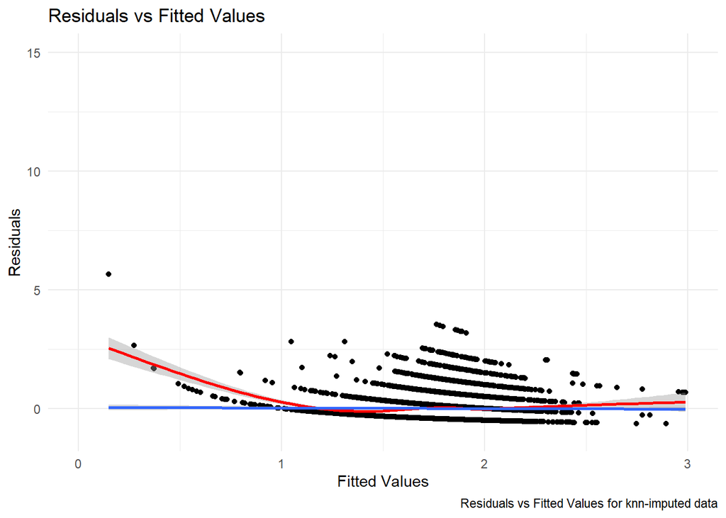

Though both graphs look very similar, the graph for knn-imputed data looks to handle clumping just slightly better than the row-removal data. For the remainder of this report, ‘poisson_model_imputed’ will be used. There is certainly clumping present, which is worth noting.

# Feature Selection

By using both backward and forward stepping and comparing the results, we can select the most important features from our model to place in the final model:

| Variable | Backward Stepping Estimate | Backward Stepping p-value | Forward Stepping Estimate | Forward Stepping p-value |
| --- | --- | --- | --- | --- |
| `sy_snum` | 0.1447 | 3.17e-07 *** | 0.1403 | 8.07e-07 *** |
| `st_mass` | — | — | -0.02786 | 0.6491 |
| `st_rad` | — | — | 0.0009943 | 0.8318 |
| `st_lum` | -0.07634 | 1.11e-07 *** | -0.05616 | 0.0542 . |
| `st_met` | -0.1258 | 0.023 * | -0.1238 | 0.0324 * |
| `pl_orbper` | — | — | -5.234e-05 | 0.2203 |
| `pl_orbsmax` | — | — | 0.05910 | 0.1211 |
| `pl_orbeccen` | -0.3270 | 2.44e-05 *** | -0.3588 | 2.49e-05 *** |
| `st_age` | — | — | 0.001585 | 0.6637 |
| `pl_insol` | -1.150e-04 | 1.04e-12 *** | -1.052e-04 | 6.35e-10 *** |
| `st_logg` | — | — | 0.06101 | 0.2713 |
| `st_dens` | — | — | -3.921e-04 | 0.7788 |

Both the backward and forward stepping model come to the same conclusion in regards to significant (or barely marginally significant) variables. Thus, the backward stepping model is probably a better choice in its simplicity.

The backward stepping model scores as a 1 on the chi-squared test, meaning that there is no evidence the model is a bad fit:

```
[1] 1
```

The dispersion parameter is below 1, which signifies a lack of overdispersion.

```
[1] 0.754815
```

Despite EDA showing some possible multicollinearity problems, our final model does not include any variables with multicollinearity issues, as all have a VIF between 1.0 and 1.2.

```
    sy_snum      st_lum      st_met pl_orbeccen    pl_insol
   1.059595    1.175783    1.021982    1.043450    1.196069
```

The residuals vs fitted graph shows a decent amount of clustering, which is worth being concerned about.

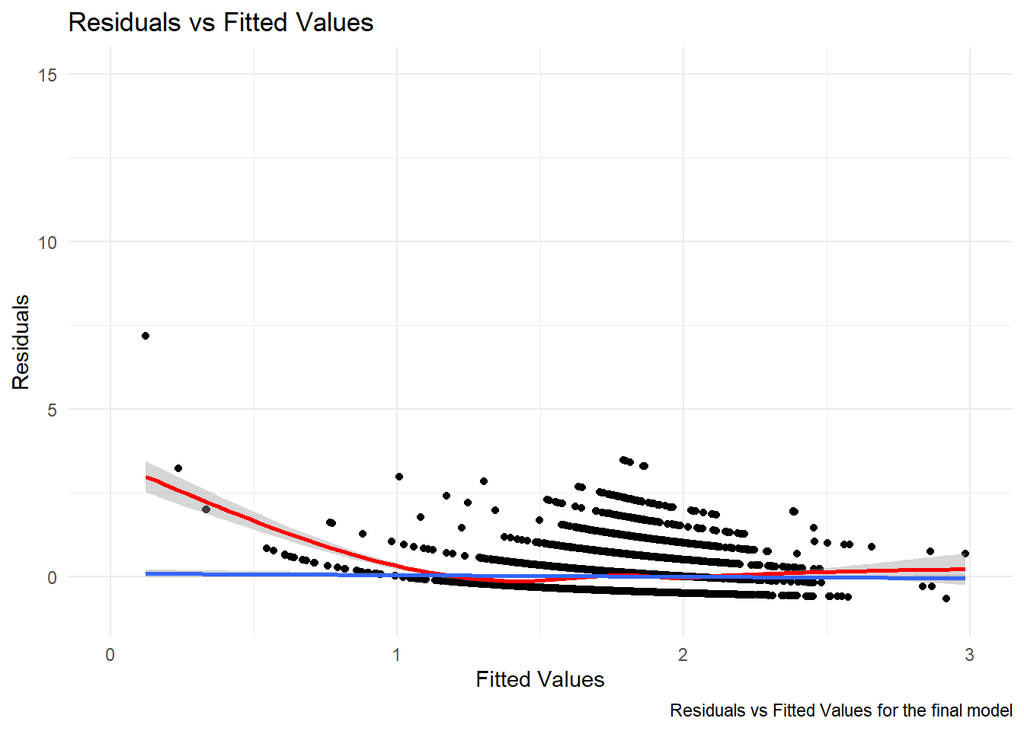

| Variable | Coefficient Estimate | p-value |
| --- | --- | --- |
| `sy_snum` | 0.1447 | 3.17e-07 *** |
| `st_lum` | -0.07634 | 1.11e-07 *** |
| `st_met` | -0.1258 | 0.023 * |
| `pl_orbeccen` | -0.3270 | 2.44e-05 *** |
| `pl_insol` | -1.150e-04 | 1.04e-12 *** |

The coefficients can be interpreted by exponentiating them, giving the following normal language interpretations:

> For each additional star in a system (sy_snum), the expected number of planets increases by 15.57%.

> For each unit increase in stellar luminosity, the expected number of planets decreases by 7.35%.

> For each unit increase in stellar metallicity, the expected number of planets decreases by 11.82%.

> For each unit increase in planetary orbital eccentricity, the expected number of planets decreases by 27.89%

> For each unit increase in insolation flux, the expected number of planets decreases by .01%.

# Conclusion

According to our final model, it seems that ‘sy_snum’ (number of stars), ‘st_lum’ (luminosity of stars), ‘st_met’ (stellar metallacity), ‘pl_orbeccen’ (eccentricity of orbit), and ‘pl_insol’ (insolation flux) are the most important factors when determining the number of exoplanets in an star system.

These are very intriguing results for the science - some of these factors, like eccentricity, stellar metallicity, and insolation flux are not intuitively tied to the number of planets in a system.

Missing data is the greatest area for improvement in this model. The p-significant variables changed depending on how the missing data was accounted for, which could make a big difference when physicists are building star system models.

Machine learning could also be implemented in the future to capture ‘feature importance’ by means of different algorithms than the ones we are exposed to in this class.